# Lab 10 - Trees, Bagging, Random Forest

```r
#knitr::opts_chunk$set(eval = F, include  = T)
```

# Learning goals

- Perform classification and regression with tree-based methods in R
- Recognize that tree-based methods are capable of capturing non-linearities by splitting multiple times on the same variables
- Compare the performance of classification trees, bagging,and random forests for predicting heart disease based on the `heart` data.

# Lab description

For this lab we will be working with simulated data and the `heart` dataset that you can download from [here](https://github.com/JSC370/jsc370-2022/blob/main/data/heart/heart.csv)

### Setup packages

You should install and load `rpart` (trees), `randomForest` (random forest), `gbm` (gradient boosting) and `xgboost` (extreme gradient boosting).

## Question 1: Trees with simulated data

- Simulate data from a random uniform distribution [-5,5] and normally distributed errors (s.d = 0.5)
- Create a non-linear relationship y=sin(x)+error
- Split the data into test and training sets (500 points each), plot the data

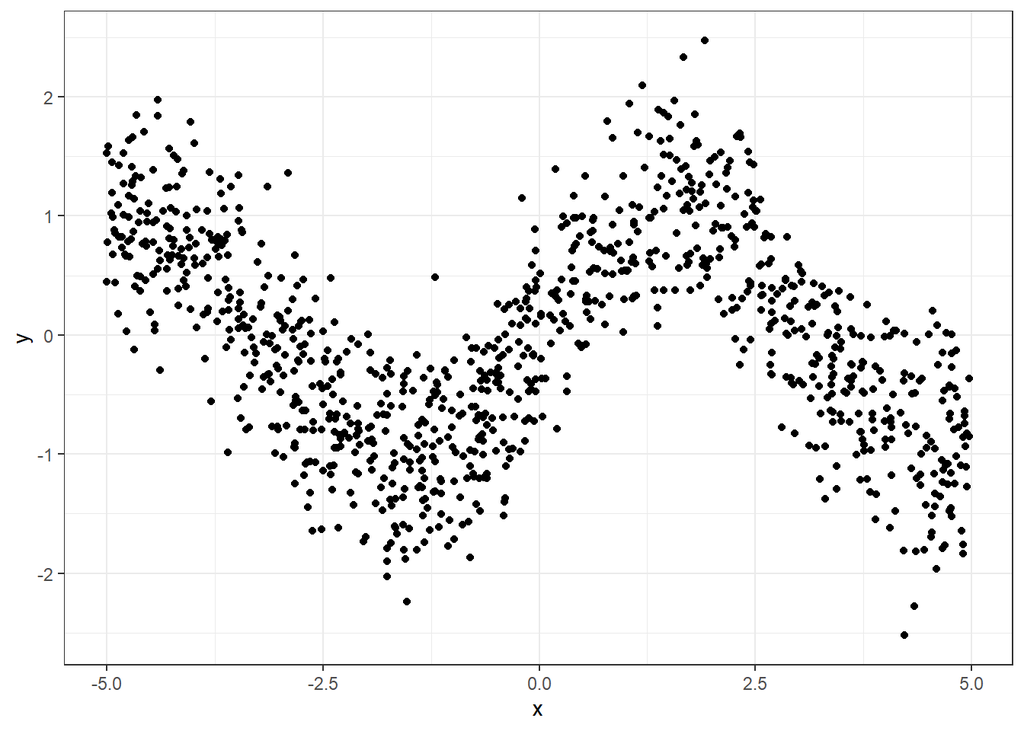

- Fit a regression tree using the training set, plot it

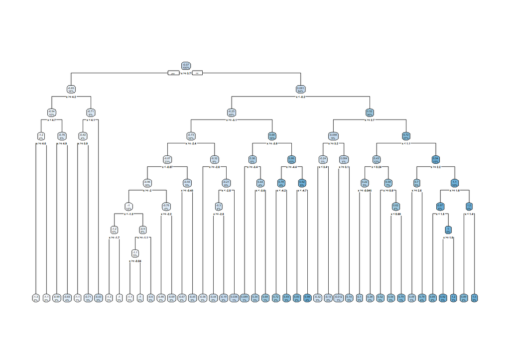

- Determine the optimal complexity parameter (cp) to prune the tree

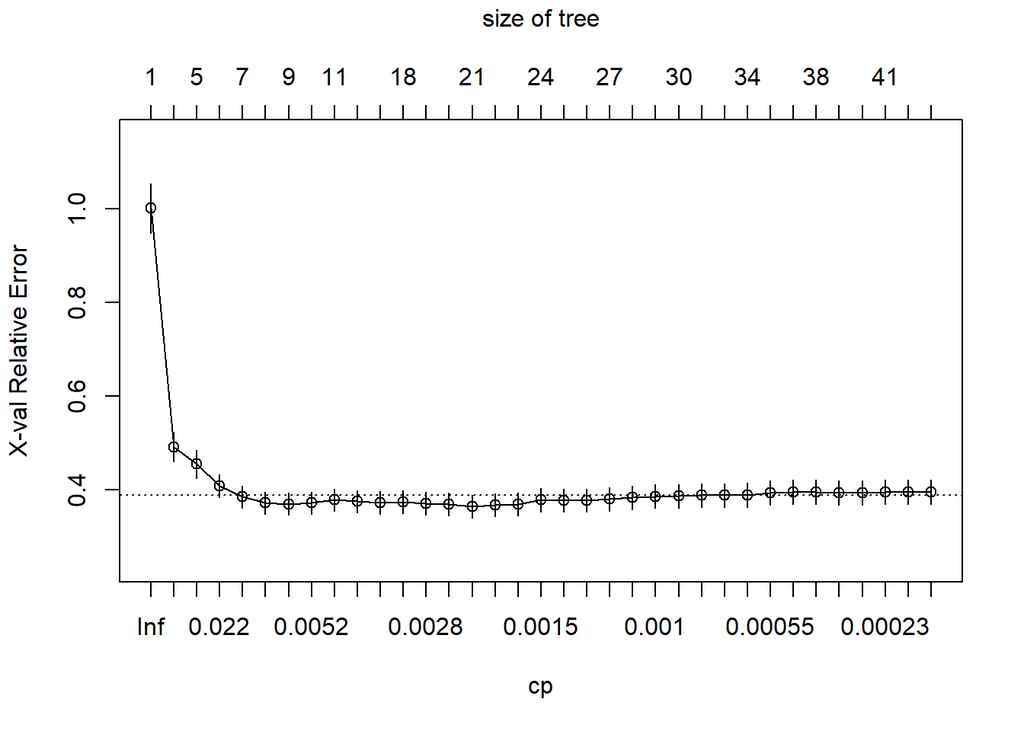

Based off of this plot, it looks like the complexity parameter which minimizes the overall error occurs with approximately 21 splits. Based on the results of the `printcp` function, we find that the overall error is minimized with 20 splits (instead of 21), with a complexity parameter of 0.00138359.

- Prune and plot the tree and summarize

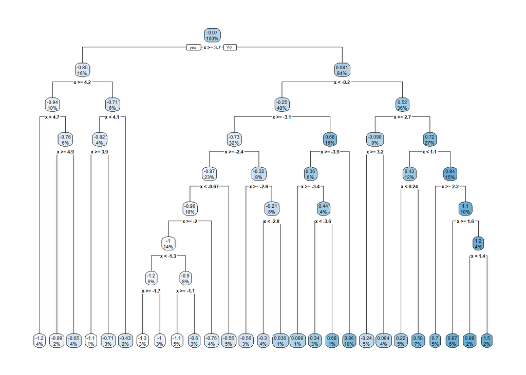

- Based on the plot and/or summary of the pruned tree create a vector of the (ordered) split points for variable x, and a vector of fitted values for the intervals determined by the split points of x.

```
##          x          x          x          x          x          x          x
## -3.9230122 -3.5763856 -3.4212958 -3.1236104 -2.7547805 -2.6282239 -2.3929936
##          x          x          x          x          x          x          x
## -1.9557760 -1.7133394 -1.2628109 -1.0507779 -0.6747309 -0.2033727  0.2440934
##          x          x          x          x          x          x          x
##  1.1344289  1.3697807  1.5881563  2.2168154  2.6875165  3.1899930  3.6521511
##          x          x          x          x          x
##  3.8597722  4.0581820  4.2207279  4.6643519  4.8653520
```

```
##  [1] -1.17972914 -0.99006115 -0.64828567 -1.05056242 -0.70760323 -0.43309714
##  [7] -1.30724558 -1.01870607 -1.08794340 -0.60004378 -0.76225871 -0.54951004
## [13] -0.55592420 -0.29761996  0.03606274  0.08948421  0.33653976  0.67669726
## [19]  0.86288842 -0.24308923  0.08385469  0.21692406  0.58164257  0.69677241
## [25]  0.97164104  0.88957602  1.53628811
```

- plot the step function corresponding to the fitted (pruned) tree

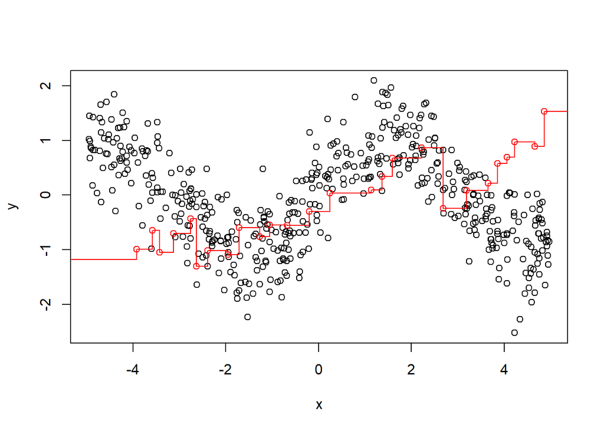

- Fit a linear model to the training data and plot the regression line.
- Contrast the quality of the fit of the tree model vs. linear regression by inspection of the plot
- Compute the test MSE of the pruned tree and the linear regression model

```
##
## Call:
## lm(formula = y ~ x, data = train_data)
##
## Residuals:
##      Min       1Q   Median       3Q      Max
## -2.25784 -0.64145 -0.04386  0.64922  2.22316
##
## Coefficients:
##             Estimate Std. Error t value Pr(>|t|)
## (Intercept) -0.06157    0.03944  -1.561    0.119
## x           -0.05500    0.01344  -4.092 4.99e-05 ***
## ---
## Signif. codes:  0 '***' 0.001 '**' 0.01 '*' 0.05 '.' 0.1 ' ' 1
##
## Residual standard error: 0.8806 on 498 degrees of freedom
## Multiple R-squared:  0.03253,    Adjusted R-squared:  0.03058
## F-statistic: 16.74 on 1 and 498 DF,  p-value: 4.993e-05
```

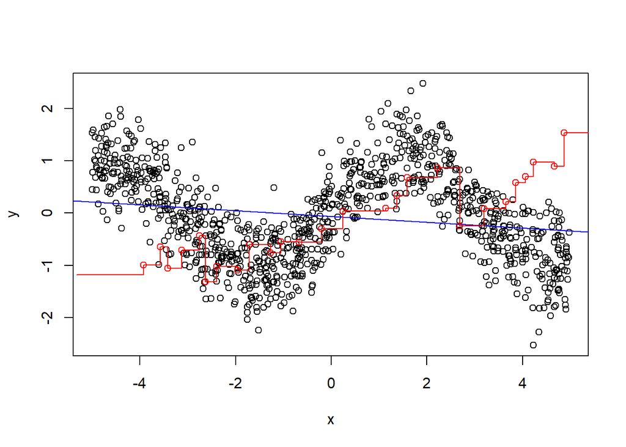

- Is the lm or regression tree better at fitting a non-linear function?

The regression tree’s corresponding step function appears to be a little better at fitting the non-linear function, but neither of these functions are particularly good at fitting the true underlying distribution.

The mean squared error for the regression tree is 0.3066385, whereas the mean squared error for the linear regression model is 0.7581756, which is significantly larger. Since the linear model has a significantly higher MSE, it is a worse fit for the overall data.

## Question 2: Analysis of Real Data

- Split the `heart` data into training and testing (70-30%)
- Fit a classification tree using rpart, plot the full tree

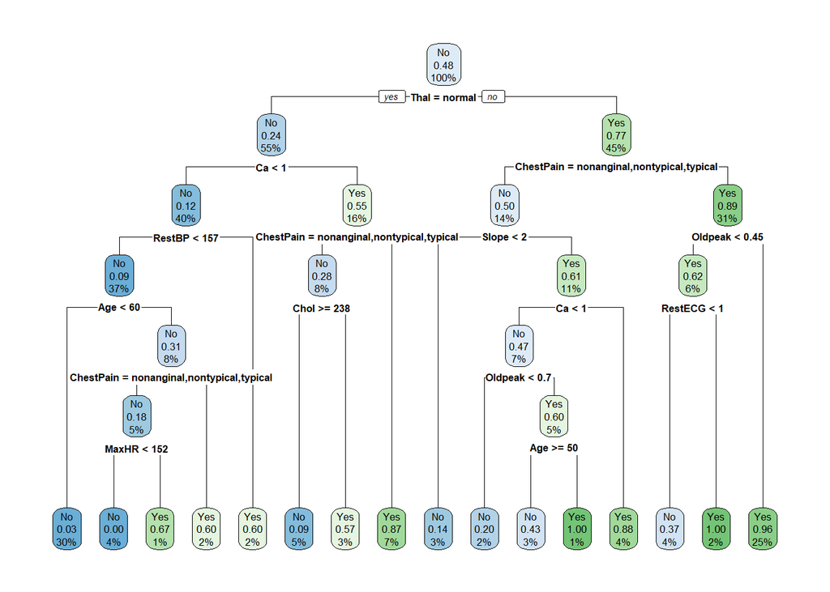

- Plot the complexity parameter table for an rpart fit and prune the tree

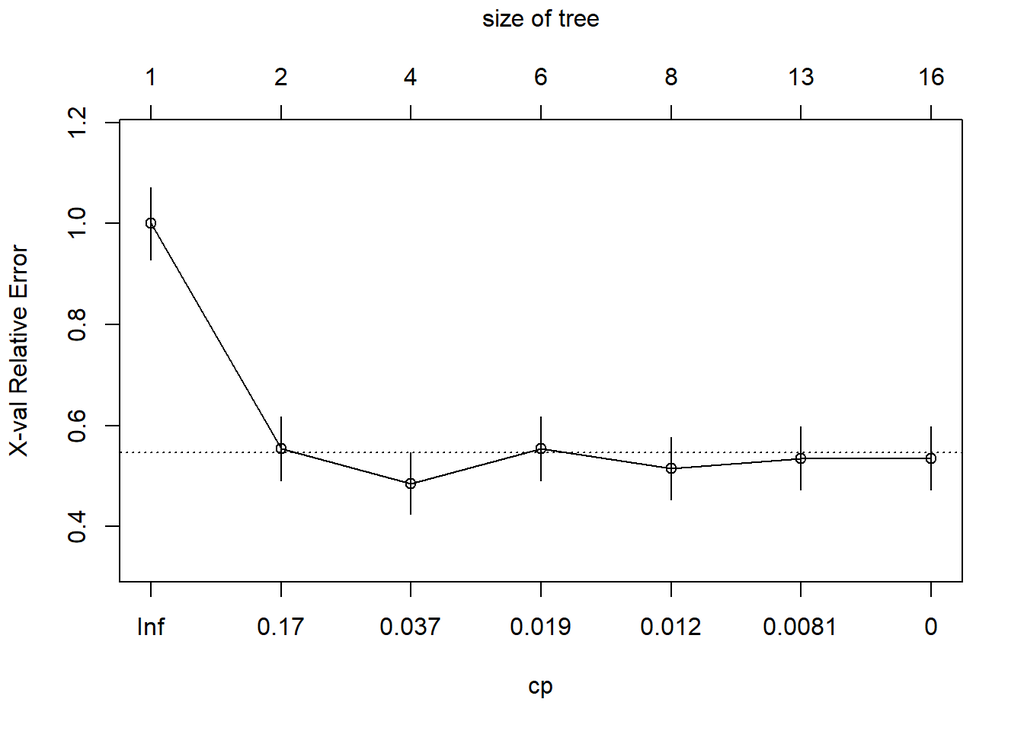

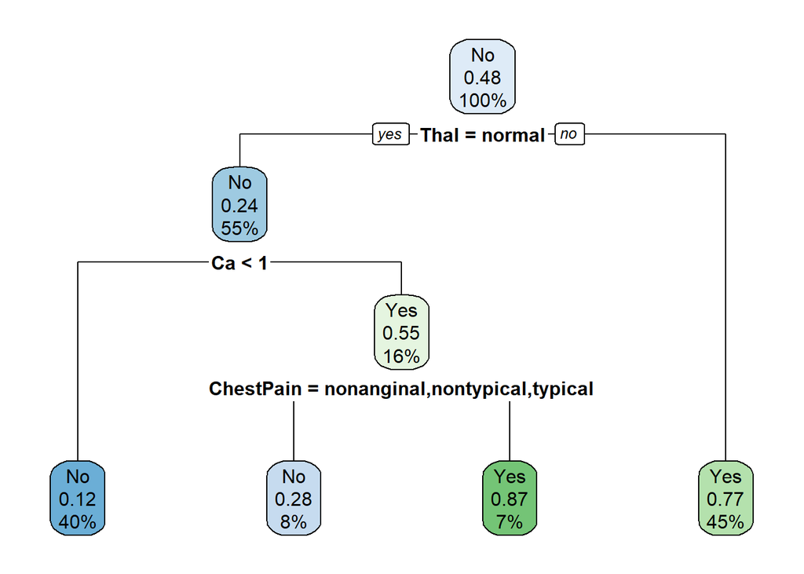

```
##      predicted
## true  no yes
##   No  39  14
##   Yes  6  32
```

- Compute the test misclassification error

```
## [1] 0.2197802
```

- Fit the tree with the optimal complexity parameter to the full data (training + testing)

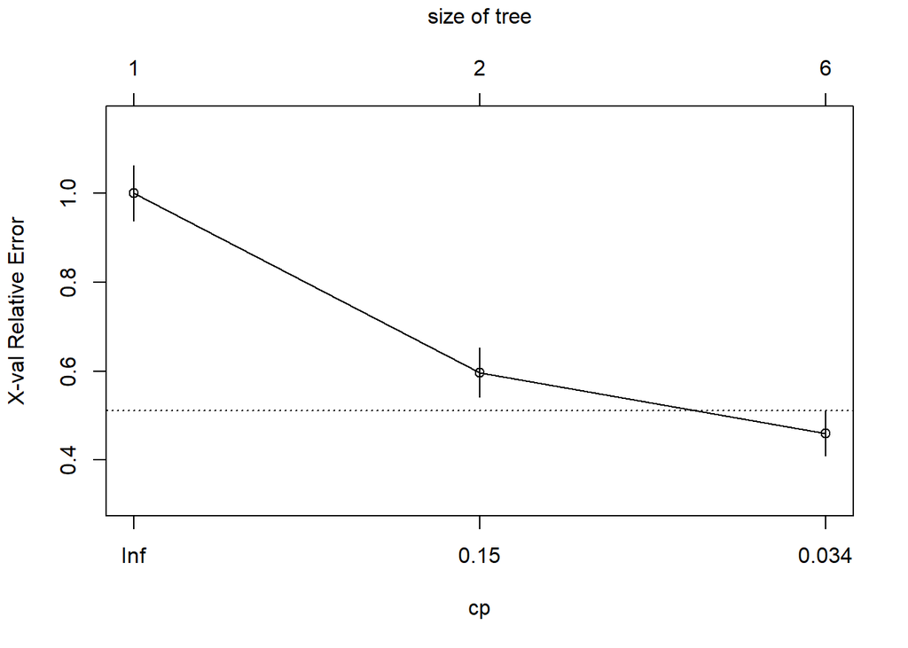

- Out of Bag (OOB) error for tree

```
##           CP nsplit rel error    xerror       xstd
## 1 0.47482014      0 1.0000000 1.0000000 0.06240124
## 2 0.04676259      1 0.5251799 0.5971223 0.05584885
## 3 0.02475248      5 0.3381295 0.4604317 0.05111552
```

```
## [1] 139.5108
```

## Question 3: Bagging, Random Forest

- Use the training and testing sets from above. Train each of the models on the training data and extract the cross-validation (or out-of-bag error for bagging and Random forest).
- For bagging use `randomForest` with `mtry` equal to the number of features (all other parameters at their default values). Generate the variable importance plot using `varImpPlot` and extract variable importance from the `randomForest` fitted object using the `importance` function.

```
## [1] 119.1527
```

- For random forests use `randomForest` with the default parameters. Generate the variable importance plot using `varImpPlot` and extract variable importance from the `randomForest` fitted object using the `importance` function.

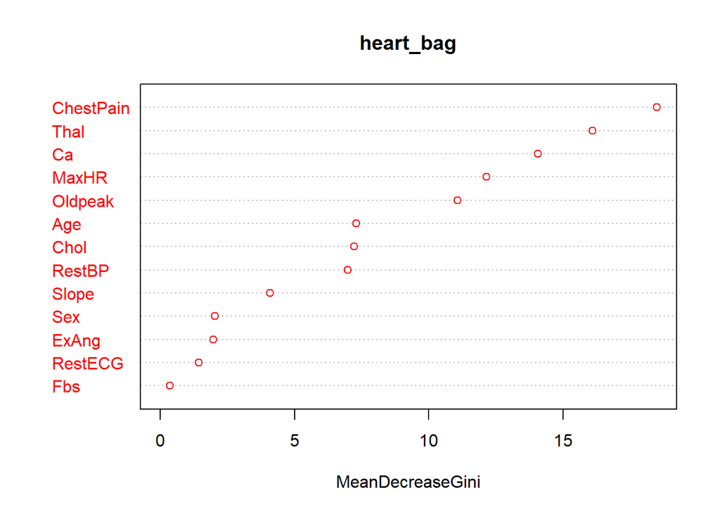

```
##           MeanDecreaseGini
## Age              7.2930159
## Sex              2.0290282
## ChestPain       18.4886629
## RestBP           6.9754269
## Chol             7.2093123
## Fbs              0.3513432
## RestECG          1.4337686
## MaxHR           12.1494964
## ExAng            1.9774185
## Oldpeak         11.0726738
## Slope            4.0948161
## Ca              14.0674606
## Thal            16.0908650
```

```
## [1] 111.6495
```

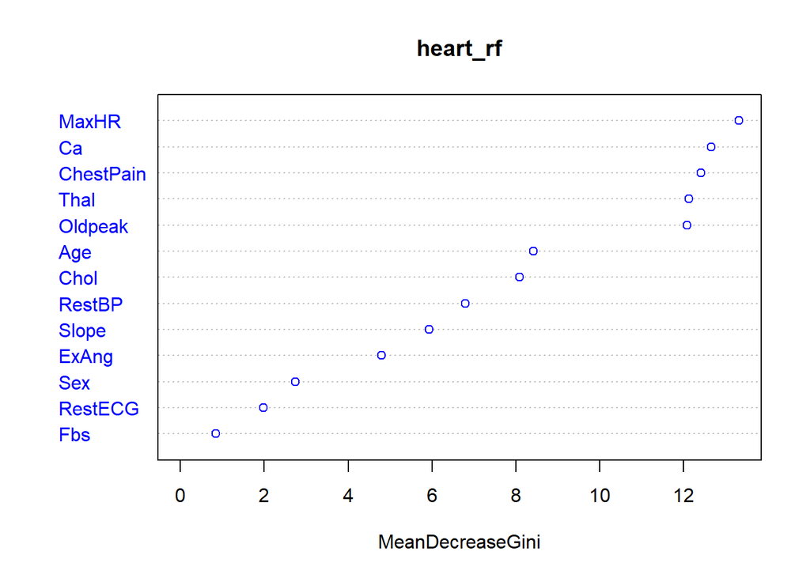

```
##           MeanDecreaseGini
## Age              8.4153940
## Sex              2.7423400
## ChestPain       12.4168620
## RestBP           6.7937383
## Chol             8.0919173
## Fbs              0.8396021
## RestECG          1.9820545
## MaxHR           13.3130687
## ExAng            4.7956684
## Oldpeak         12.0837949
## Slope            5.9311566
## Ca              12.6549891
## Thal            12.1249560
```

# Question 4: Boosting (Will be done in Lab 11 instead)

- For boosting use `gbm` with `cv.folds=5` to perform 5-fold cross-validation, and set `class.stratify.cv` to `AHD` (heart disease outcome) so that cross-validation is performed stratifying by `AHD`. Plot the cross-validation error as a function of the boosting iteration/trees (the `$cv.error` component of the object returned by `gbm`) and determine whether additional boosting iterations are warranted. If so, run additional iterations with `gbm.more` (use the R help to check its syntax). Choose the optimal number of iterations. Use the `summary.gbm` function to generate the variable importance plot and extract variable importance/influence (`summary.gbm` does both). Generate 1D and 2D marginal plots with `gbm.plot` to assess the effect of the top three variables and their 2-way interactions.

# Deliverables

1. Questions 1-3 (we removed Q4) answered, pdf or html output uploaded to Quercus